# Későneutron-paraméterek vizsgálata

A következő slide-showban nyomon követhetjük a későneutron-paraméterek vizsgálatáról szóló jegyzőkönyv kiértékelésének folyamatát.

Mindenek előtt töltsük be a besugárzott, majd neutrondetektorba helyezett minta okozta beütéseket tartalmazó fájlt, és ellenőrizzük le, hogy valóban a várt, csökkenő exponenciális profilú függvényt kapjuk-e.

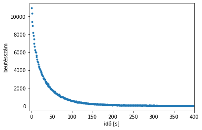

```python
data=loadtxt("F1.txt")   #betöltés
t=range(len(data))
xlim(-5, 400)
xlabel("idő [s]")    #ábrafeliratok
ylabel("beütésszám")
plot(t, data, 'o', ms=3)   #ábrázolás
```

Valóban a várt alakot kaptunk, így hozzáláthatunk az adatok logaritmizálásának annak érdekében, hogy szétválogassuk a **későneutron-családokat**.

## Első módszer a későneutron-családok meghatározására

A logaritmitált adatsor **lineáris darabokat** fog tartalmazni, definiáljuk az illesztendő lineáris függvényt!

```python
def linear(x, a, b):    #a definiált lineáris függvény
    return a*x+b
```

Nézzük most meg a logaritmizált értékeket, annak érdekében, hogy kiválaszthassuk a legkésőbbi egyenes szakaszt!

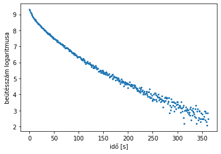

```python
logdata=log(data)   #a beolvasott értékek logaritmusa
xlabel("idő [s]")    #tengelyfeliratok
ylabel("beütésszám logaritmusa")
plot(t, logdata, "o", ms=2)     #ábrázolás
```

Látjuk, hogy kicsivel 200 után kezdődik és körülbelül 360-ig tart a szakasz.

Illesszünk rá!

```python
t1=range(220, 360)    #kiválasztott időtartomány
logdata1=logdata[220:360]    #kiválasztott adattartomány
```

```
[-0.01288041  7.13408539]
[0.00047134 0.13777567]
```

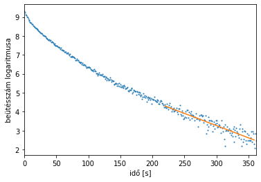

```python
popt1, pcov1 = curve_fit(linear, t1, logdata1)   #illesztés
print(popt1)  #az illesztés paraméteri
err1=sqrt(diag(pcov1))   #számoljunk hibát
print(err1)   #írjunk ki hibát
xlim(0, 362)   #xtengely hatérai
xlabel("idő [s]")    #ábrafeliratok
ylabel("beütésszám logaritmusa")
plot(t, logdata, "o", ms=1)   #ábrázolások
plot(t1, linear(t1, *popt1))
```

Az első illesztésünk láthatóan sikeres volt.

Ezután két feladatunk van:

- Vonjuk le a leghosszabb felezési idejű későneutron-család járulékát!
- Illesszünk a következő egyenes szakaszra!

```python
logdata1=linear(t, popt1[0], popt1[1])   #kiszámoljuk a lh felezési idejű család járulékénak logaritmusát
data1=e**logdata1    #ezt visszaexponencializáljuk
logdata02=log(data-data1)    #levonjuk
```

```python
logdata2=logdata02[42:139]    #kijelöljük az adattartományt
t2=range(42, 139)     #az időtartományt
```

```
[-0.03360617  8.73511217]
[0.00046679 0.04399767]
```

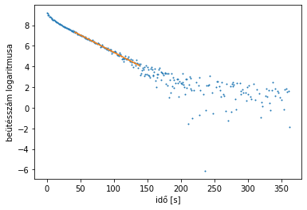

```python
popt2, pcov2 = curve_fit(linear, t2, logdata2)    #illesztés
print(popt2)    #illesztési paraméterek kiíratása
err2=sqrt(diag(pcov2))    #számolja a hibát
print(err2)    #kiírja ahibát
xlabel("idő [s]")   #tengelyfeliratok
ylabel("beütésszám logaritmusa")
plot(t, logdata02, "o", ms=1)   #ábrázolások
plot(t2, linear(t2, *popt2))
```

Most is megfelelő az illesztés, az *előzőhöz* hasonlóan járunk el.

```python
logdata2=linear(t, popt2[0], popt2[1])    #kiszámoljuk a következő felezési idejű család járulékénak logaritmusát
data2=e**logdata2    #ezt visszaexponencializáljuk
logdata03=log(data-data1-data2)    #levonjuk

logdata3=logdata03[0:17]    #kijelöljük az adattartományt
t3=range(0,17)    #időtartományt
```

```
[-0.1784694   8.12991026]
[0.00574403 0.05388375]
```

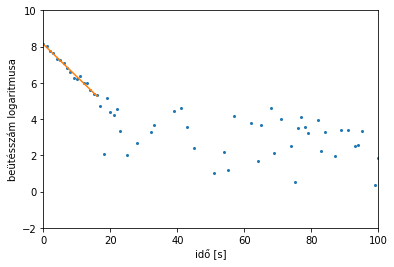

```python
ylim(-2, 10)   #x tengely határai
xlim(0, 100)   #y tengely határai
popt3, pcov3 = curve_fit(linear, t3, logdata3)   #illesztés
print(popt3)    #kiírja az illestési paramétereket
err3=sqrt(diag(pcov3))    #hibát számol
print(err3)    #hibát kiír
xlabel("idő [s]")    #tengelyfeliratok
ylabel("beütésszám logaritmusa")
plot(t, logdata03, "o", ms=2)    #ábrázolások
plot(t3, linear(t3, *popt3))
```

Itt már lényegesen kevesebb pont van, de az **illesztési paraméterek** és a **hibák** *elfogadhatóak*.

## Második módszer a későneutron-családok meghatározására

Ezúttal nem logaritmizáljuk az adatokat, hanem exponenciális függvények összegét illesztjük. Szükségünk esz kezőparaméterekre, erre acélra alkalmasak az előbbiekben kapott értékek.

Nézzük az illesztést!

```python
def exponential(t, nu1, lambda1, nu2, lambda2, nu3, lambda3):   #definiáljuk az exponenciális függvényt
    return nu1*e**(-lambda1*t)+nu2*e**(-lambda2*t)+nu3*e**(-lambda3*t)
```

```
[1.71346215e+03 1.43703009e-02 5.85715551e+03 3.60232065e-02
 3.42632558e+03 1.87597729e-01]
[2.99560691e+01 9.15045245e-05 2.17309561e+01 1.68547144e-04
 1.24937443e+01 8.03974969e-04]
```

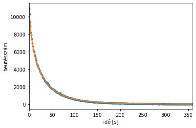

```python
popt, pcov = curve_fit(exponential, t, data, p0=[e**popt1[1], -popt1[0], e**popt2[1], -popt2[0], e**popt3[1], -popt3[0]]) #illesztünk az előző eredmények felhasználásával
plot(t, data, "o", ms=3)   #ábrázoljuk
plot(t, exponential(t, *popt), lw=2)
print(popt)   #kiírja az illesztési paramétereket
err=sqrt(diag(pcov))    #hibát számol
print(err)    #hibát kiír
xlim(0, 360);   #xtengely határai
xlabel("idő [s]");   #tengelyfeliratok
ylabel("beütésszám");
```

Az kezdőparamétekenek köszönhetően ez is viszonylag szép illesztést adott, de az [irodalmi értékekkel](https://en.wikipedia.org/wiki/Delayed_neutron#Fraction_definitions) összevetve azt tapasztaljuk, hogy a logaritmizáló módszer hatékonyabb.

## Ismeretlen minta urántartalmának meghatározása

Ehhez a feladathoz csak a beolvasásokat végeztem a notebook segítségével, a többi számológéppel egyzserűbben elvégezhető volt.

```python
hatter=loadtxt("background.TKA")   #az üres tok adatai
S7=loadtxt("S7.TKA")   #az első standard
S8=loadtxt("S8.TKA")   #a második standard
unknown=loadtxt("unknown.TKA")   #az ismeretlen minta
```

A beütések **összege** hordozott releváns információt, így elvégeztem a szummázásokat.

```python
NX=sum(unknown[20:80])   #az ismeretlen minta beütéseinek összege
NS7=sum(S7[20:80])   #az első standard beütéseinek összege
NS8=sum(S8[20:80])   #a második standard beütéseinek összege
H=sum(hatter[20:80])  #a háttér beütéseinek összege
mX=105.5 #mg   #egyes tömegek
mS7=93.3 #mg
mS8=85.1 #mg
CS7=0.501 #tömeg%    #az ismert koncentrációk
CS8=0.135 #tömeg%
print("N_x=")
print(NX)
print("N_S7=")
print(NS7)
print("N_S8=")
print(NS8)
print("hatter=")
print(H)
```

```
N_x=
7211.0
N_S7=
9767.0
N_S8=
2626.0
hatter=
22.0
```